# Welcome to Tools for Analytics

## About Me

- Lars Relund Nielsen (larsrn@econ.au.dk)
- Professor at Dept. of Economics and Business Economics, Aarhus Universitet.
- I do research in algorithms for optimization, multiobjective optimization, stochastic dynamic programming
- Are programming in all kinds of languages such as C, C++, VBA, R, SQL, Javascript …
- For more information see my [research page](http://www.research.relund.dk/).

## Course overview

- Business Analytics (BA) refers to the scientific process of transforming data into insight for making better decisions in business.
- There is an increasing need for analysts with the ability to do tasks within Analytics.
- This requires for the analyst to be particularly qualified in handling IT based tools.
- The use of programming is the basis for performing analytical tasks such as descriptive, predictive and prescriptive analytics.
- This course gives you an introduction to different tools to perform Analytics.
- The course is partitioned into two parts.
  - The VBA part gives you an introduction to the compiled programming language VBA (Visual Basic for Applications) in Excel.
  - The R part gives you an introduction to the interpreted programming language R.

## Analytics as a data driven process

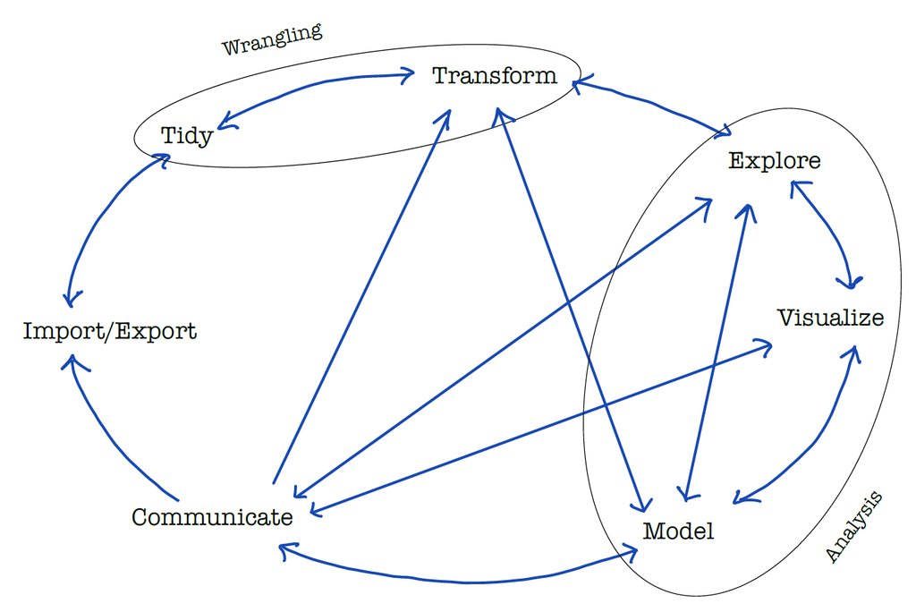

- First you must **import** your data.
- Next you must get your data in the right form (**wrangling**).
- Exploration, visualizaton and modeling may be seen as different steps which can be used for **analyzing** the data and answer the overall questions.
- Given an analysis you must **communicate** the results to decision makers.
- Surrounding the process is **programming** (your Swiss army knife).

## VBA Part

- VBA is a programming language ”behind” MS Office.
- Automate processes and create algorithms.
- Introduction to programming (i.e. coding).
- The Object model: cells, worksheets, workbooks.
- Input/Output, variables, loops, conditions, procedures.
- VBA project

## R Part

- R basics
- Programming in R (loops, conditionals and functions)
- Rmarkdown
- IO, tidy and transform
- Visualization
- R project

## Teaching form and style

- A combination of lectures and study cafés.
- Each week you will be given an on-line learning path such as
  1. Read material or do interactive tutorials and start with exercises.
  2. Lecture.
  3. Continue with exercises (group work).
  4. Join the Study café if you need help with the exercises.
- The course is a “learning by doing” course. Programming is best learned by trying it yourself given some exercises.
- The main focus is on giving you a set of exercises that you can solve in your study groups.
- It is strongly recommended that you solve the exercises for each week during the course. This is the best way to prepare for the exam.

## Groups

- You will be asked to form study groups of 3-6 persons which will be used in the whole course.
- It is up to you how to meet in these groups (on-line or physical).
- The groups will be the backbone when you solve exercises.
- It is expected that you have done some effort in understanding/solving the exercises before you meet in you group.
- The mandatory project reports also have to be handed in as groups.

## Project reports

- Two mandatory reports must be written during the course.
- Each one focus on the topics covered in the VBA and R part of the course.
- For being qualified for exam participation each student must
  1. hand in the reports in groups,
  2. do individual peer grading using the on-line platform Peergrade.
- For sign-up see Brightspace.

## Exam

- A six hour written exam about all the curriculum/topics in the course.
- Curriculum include all material such as book chapters, course notes, videos, interactive tutorials, exercises and project reports.
- Each part of the course will be given the same weight (3 hours for the VBA and R part).

## Happy coding during the course!